# Cars4U Project

by Michele Casalgrandi

#### Background

Cars4U is a tech start-up that operates in the Indian used cars market.

One of Cars4U aims is to be able to accurately predict cars market value to assist in devising profitable strategies using differential pricing.

#### Objective

1. Explore and visualize data set
2. Build a linear regression model to predict the prices of used cars
3. Generate a set of insights and recommendations that will help with the business

#### Data Dictionary

```
S.No. : Serial Number
Name : Name of the car which includes Brand name and Model name
Location : The location in which the car is being sold or is available for purchase Cities
Year : Manufacturing year of the car
Kilometers_driven : The total kilometers driven in the car by the previous owner(s) in KM.
Fuel_Type : The type of fuel used by the car. (Petrol, Diesel, Electric, CNG, LPG)
Transmission : The type of transmission used by the car. (Automatic / Manual)
Owner_Type : Type of ownership
Mileage : The standard mileage offered by the car company in kmpl or km/kg
Engine : The displacement volume of the engine in CC.
Power : The maximum power of the engine in bhp.
Seats : The number of seats in the car.
New_Price : The price of a new car of the same model in INR Lakhs.(1 Lakh = 100, 000)
Price : The price of the used car in INR Lakhs (1 Lakh = 100, 000)
```

### Preliminary Data Pre-processing

##### Import libraries and data

```python
import pandas as pd
import numpy as np
import matplotlib.pyplot as plt
import seaborn as sns

sns.set()

import warnings

warnings.filterwarnings("ignore")

# Removes the limit for the number of displayed columns
pd.set_option("display.max_columns", None)
# Sets the limit for the number of displayed rows
pd.set_option("display.max_rows", 200)

# To build linear model for prediction
from sklearn.linear_model import LinearRegression

# To check model performance
from sklearn.metrics import mean_squared_error, r2_score, mean_absolute_error
```

```python
# Load data set
df = pd.read_csv('used_cars_data.csv')
# Create a copy for data pre-processing
cars = df.copy()
```

```python
# set random seed to ensure consistent results between runs
np.random.seed(1)
```

```python
# display a sample of the data
cars.sample(5)
```

|  | S.No. | Name | Location | Year | Kilometers_Driven | Fuel_Type | Transmission | Owner_Type | Mileage | Engine | Power | Seats | New_Price | Price |
| --- | --- | --- | --- | --- | --- | --- | --- | --- | --- | --- | --- | --- | --- | --- |
| 2397 | 2397 | Ford EcoSport 1.5 Petrol Trend | Kolkata | 2016 | 21460 | Petrol | Manual | First | 17.0 kmpl | 1497 CC | 121.36 bhp | 5.0 | 9.47 Lakh | 6.00 |
| 3777 | 3777 | Maruti Wagon R VXI 1.2 | Kochi | 2015 | 49818 | Petrol | Manual | First | 21.5 kmpl | 1197 CC | 81.80 bhp | 5.0 | 5.44 Lakh | 4.11 |
| 4425 | 4425 | Ford Endeavour 4x2 XLT | Hyderabad | 2007 | 130000 | Diesel | Manual | First | 13.1 kmpl | 2499 CC | 141 bhp | 7.0 | NaN | 6.00 |
| 3661 | 3661 | Mercedes-Benz E-Class E250 CDI Avantgrade | Coimbatore | 2016 | 39753 | Diesel | Automatic | First | 13.0 kmpl | 2143 CC | 201.1 bhp | 5.0 | NaN | 35.28 |
| 4514 | 4514 | Hyundai Xcent 1.2 Kappa AT SX Option | Kochi | 2016 | 45560 | Petrol | Automatic | First | 16.9 kmpl | 1197 CC | 82 bhp | 5.0 | NaN | 6.34 |

```python
cars.shape
```

```
(7253, 14)
```

The data set is comprised of 7253 observations, each with 14 features

```python
# display data statistics
cars.describe(include='all').T
```

|  | count | unique | top | freq | mean | std | min | 25% | 50% | 75% | max |
| --- | --- | --- | --- | --- | --- | --- | --- | --- | --- | --- | --- |
| S.No. | 7253 | NaN | NaN | NaN | 3626 | 2093.91 | 0 | 1813 | 3626 | 5439 | 7252 |
| Name | 7253 | 2041 | Mahindra XUV500 W8 2WD | 55 | NaN | NaN | NaN | NaN | NaN | NaN | NaN |
| Location | 7253 | 11 | Mumbai | 949 | NaN | NaN | NaN | NaN | NaN | NaN | NaN |
| Year | 7253 | NaN | NaN | NaN | 2013.37 | 3.25442 | 1996 | 2011 | 2014 | 2016 | 2019 |
| Kilometers_Driven | 7253 | NaN | NaN | NaN | 58699.1 | 84427.7 | 171 | 34000 | 53416 | 73000 | 6.5e+06 |
| Fuel_Type | 7253 | 5 | Diesel | 3852 | NaN | NaN | NaN | NaN | NaN | NaN | NaN |
| Transmission | 7253 | 2 | Manual | 5204 | NaN | NaN | NaN | NaN | NaN | NaN | NaN |
| Owner_Type | 7253 | 4 | First | 5952 | NaN | NaN | NaN | NaN | NaN | NaN | NaN |
| Mileage | 7251 | 450 | 17.0 kmpl | 207 | NaN | NaN | NaN | NaN | NaN | NaN | NaN |
| Engine | 7207 | 150 | 1197 CC | 732 | NaN | NaN | NaN | NaN | NaN | NaN | NaN |
| Power | 7207 | 386 | 74 bhp | 280 | NaN | NaN | NaN | NaN | NaN | NaN | NaN |
| Seats | 7200 | NaN | NaN | NaN | 5.27972 | 0.81166 | 0 | 5 | 5 | 5 | 10 |
| New_Price | 1006 | 625 | 4.78 Lakh | 6 | NaN | NaN | NaN | NaN | NaN | NaN | NaN |
| Price | 6019 | NaN | NaN | NaN | 9.47947 | 11.1879 | 0.44 | 3.5 | 5.64 | 9.95 | 160 |

Checking for missing values

```python
# Get null values
cars.isnull().sum()
```

```
S.No.                   0
Name                    0
Location                0
Year                    0
Kilometers_Driven       0
Fuel_Type               0
Transmission            0
Owner_Type              0
Mileage                 2
Engine                 46
Power                  46
Seats                  53
New_Price            6247
Price                1234
dtype: int64
```

The majority of rows are missing a value for 'New_Price'. We will drop that column from the dataset.

```python
# drop New_Price
cars.drop('New_Price', axis=1, inplace=True)
```

```python
# check for nulls
cars.isnull().sum()
```

```
S.No.                   0
Name                    0
Location                0
Year                    0
Kilometers_Driven       0
Fuel_Type               0
Transmission            0
Owner_Type              0
Mileage                 2
Engine                 46
Power                  46
Seats                  53
Price                1234
dtype: int64
```

Many rows are missing a value for 'Price'. Since 'Price' is what we want to predict, those rows cannot be used for training a model. We will drop rows where price is null.

```python
# drop null Price rows
records_without_price = cars[cars['Price'].isnull()].index
cars.drop(records_without_price, axis=0, inplace=True)

# check for nulls
cars.isnull().sum()
```

```
S.No.                 0
Name                  0
Location              0
Year                  0
Kilometers_Driven     0
Fuel_Type             0
Transmission          0
Owner_Type            0
Mileage               2
Engine               36
Power                36
Seats                42
Price                 0
dtype: int64
```

There are two rows with missing mileage.

```python
# view null Mileage records
cars[cars.Mileage.isnull()]
```

|  | S.No. | Name | Location | Year | Kilometers_Driven | Fuel_Type | Transmission | Owner_Type | Mileage | Engine | Power | Seats | Price |
| --- | --- | --- | --- | --- | --- | --- | --- | --- | --- | --- | --- | --- | --- |
| 4446 | 4446 | Mahindra E Verito D4 | Chennai | 2016 | 50000 | Electric | Automatic | First | NaN | 72 CC | 41 bhp | 5.0 | 13.00 |
| 4904 | 4904 | Toyota Prius 2009-2016 Z4 | Mumbai | 2011 | 44000 | Electric | Automatic | First | NaN | 1798 CC | 73 bhp | 5.0 | 12.75 |

Mileage is available for both models online. We will impute the value for the *Toyota Prius*.

However, for the Mahindra, its value is so high (110 kmpl) that it will heavily skew the data.

As it is one of only two observations for Electric cars, we will deal with it later on rather than dropping it.

```python
# source google search:

# https://www.google.com/search?q=Mahindra+E+Verito+D4+mileage
# will not use for now due to being an extreme outlier
# cars['Mileage'].loc[4446] = '110 kmpl'

# https://www.google.com/search?&q=Toyota+Prius+2009-2016+Z4+mileage
cars['Mileage'].loc[4904] = '23.91 kmpl'
```

```python
# check for nulls
cars.isnull().sum()
```

```
S.No.                 0
Name                  0
Location              0
Year                  0
Kilometers_Driven     0
Fuel_Type             0
Transmission          0
Owner_Type            0
Mileage               1
Engine               36
Power                36
Seats                42
Price                 0
dtype: int64
```

Checking for null 'Engine' values

```python
cars[cars['Engine'].isnull()].sample(10)
```

|  | S.No. | Name | Location | Year | Kilometers_Driven | Fuel_Type | Transmission | Owner_Type | Mileage | Engine | Power | Seats | Price |
| --- | --- | --- | --- | --- | --- | --- | --- | --- | --- | --- | --- | --- | --- |
| 4229 | 4229 | Hyundai Santro Xing XG | Bangalore | 2005 | 79000 | Petrol | Manual | Second | 17.0 kmpl | NaN | NaN | NaN | 1.65 |
| 4577 | 4577 | BMW 5 Series 520d Sedan | Delhi | 2012 | 72000 | Diesel | Automatic | Third | 18.48 kmpl | NaN | NaN | NaN | 13.85 |
| 3810 | 3810 | Honda CR-V AT With Sun Roof | Kolkata | 2013 | 27000 | Petrol | Automatic | First | 14.0 kmpl | NaN | NaN | NaN | 11.99 |
| 733 | 733 | Maruti Swift 1.3 VXi | Chennai | 2006 | 97800 | Petrol | Manual | Third | 16.1 kmpl | NaN | NaN | NaN | 1.75 |
| 4712 | 4712 | Hyundai Santro Xing XG | Pune | 2003 | 80000 | Petrol | Manual | Second | 17.0 kmpl | NaN | NaN | NaN | 0.90 |
| 5185 | 5185 | Maruti Swift 1.3 LXI | Delhi | 2012 | 52000 | Petrol | Manual | First | 16.1 kmpl | NaN | NaN | NaN | 3.65 |
| 3522 | 3522 | Hyundai Santro GLS II - Euro II | Kochi | 2012 | 66400 | Petrol | Manual | First | 0.0 kmpl | NaN | NaN | NaN | 2.66 |
| 4011 | 4011 | Fiat Punto 1.3 Emotion | Pune | 2011 | 45271 | Diesel | Manual | First | 20.3 kmpl | NaN | NaN | NaN | 2.60 |
| 5015 | 5015 | Maruti Swift 1.3 VXi | Delhi | 2006 | 63000 | Petrol | Manual | First | 16.1 kmpl | NaN | NaN | NaN | 1.60 |
| 1294 | 1294 | Honda City 1.3 DX | Delhi | 2009 | 55005 | Petrol | Manual | First | 12.8 kmpl | NaN | NaN | NaN | 3.20 |

Most cars that are missing 'Engine' value are also missing 'Power' and 'Seats'

Most of these values can be found online and imputed.

However, considering that they account for less than 1% of the observations and in the interest of time, we will drop observations without these values.

```python
# loop through the applicable columns and drop rows with nulls
columns_drop_nulls = ['Engine','Power','Seats']
for col in columns_drop_nulls:
    records_with_nulls = cars[cars[col].isnull()]
    cars.drop(records_with_nulls.index, axis=0, inplace=True)

cars.isnull().sum()
```

```
S.No.                0
Name                 0
Location             0
Year                 0
Kilometers_Driven    0
Fuel_Type            0
Transmission         0
Owner_Type           0
Mileage              1
Engine               0
Power                0
Seats                0
Price                0
dtype: int64
```

Checking for duplicates

```python
# Get duplicate rows, if any
cars.duplicated().sum()
```

```
0
```

There are no duplicate rows.

Reviewing data types

```python
# Get data types
cars.dtypes
```

```
S.No.                  int64
Name                  object
Location              object
Year                   int64
Kilometers_Driven      int64
Fuel_Type             object
Transmission          object
Owner_Type            object
Mileage               object
Engine                object
Power                 object
Seats                float64
Price                float64
dtype: object
```

Five are numerical (S.No., Year, Kilometers_Driven, Seats, Price), the rest are of type object.

Some variables, which are expected to be numerical, are of type object (Mileage, Power, Engine). We will explore those variables next.

```python
object_to_num_columns = ['Mileage','Power','Engine']
for column in object_to_num_columns:
    print(f'\n{cars[column].value_counts().head(10)}')
```

```
18.9 kmpl     172
17.0 kmpl     170
18.6 kmpl     119
20.36 kmpl     88
21.1 kmpl      86
17.8 kmpl      85
16.0 kmpl      76
12.8 kmpl      70
20.0 kmpl      70
18.0 kmpl      69
Name: Mileage, dtype: int64

74 bhp       235
98.6 bhp     131
73.9 bhp     125
140 bhp      123
78.9 bhp     111
67.1 bhp     107
67.04 bhp    107
null bhp     103
82 bhp       101
88.5 bhp     100
Name: Power, dtype: int64

1197 CC    606
1248 CC    512
1498 CC    303
998 CC     259
2179 CC    240
1497 CC    229
1198 CC    227
1968 CC    216
1995 CC    183
1461 CC    152
Name: Engine, dtype: int64
```

The values contain units of measure.

We will check to see if there are multiple units of measure

```python
# function to extract the units of measure (trailing word)
def get_unit_of_measure(value):
    '''
    Return trailing unit of measure.
    Expects the number and unit of measure to be separated by a space
    '''
    if isinstance(value, str):
        return value.split(" ")[1]
    else:
        return np.nan

# extract the units of measure from the columns
for column in object_to_num_columns:
    units_of_measure = cars[column].apply(get_unit_of_measure)
    print(f'\n {column} units of measure: {units_of_measure.unique()}')
```

```
 Mileage units of measure: ['km/kg' 'kmpl' nan]

 Power units of measure: ['bhp']

 Engine units of measure: ['CC']
```

'Power' and 'Engine' have a single unit of measure.

For 'Mileage' even though 'kmpl' and 'km/kg' are not directly comparable, we will rely on the column 'Fuel_Type' in the model to help compensate for the difference in weight that unit of measure should have.

We will remove the units of measure so the columns can be converted to numeric and be used in the model.

```python
# define function to remove the trailing part of a string after the first space
def get_first_word(value, separator=" "):
    '''
    Return first word delimited by separator from a string value.
    '''
    if isinstance(value, str):
        return value.split(separator)[0]
    else:
        return np.nan

# remove units of measure for the applicable columns
for column in object_to_num_columns:
    cars[column] = cars[column].apply(get_first_word)
```

```python
# verify the result
cars[object_to_num_columns]
```

|  | Mileage | Power | Engine |
| --- | --- | --- | --- |
| 0 | 26.6 | 58.16 | 998 |
| 1 | 19.67 | 126.2 | 1582 |
| 2 | 18.2 | 88.7 | 1199 |
| 3 | 20.77 | 88.76 | 1248 |
| 4 | 15.2 | 140.8 | 1968 |
| ... | ... | ... | ... |
| 6014 | 28.4 | 74 | 1248 |
| 6015 | 24.4 | 71 | 1120 |
| 6016 | 14.0 | 112 | 2498 |
| 6017 | 18.9 | 67.1 | 998 |
| 6018 | 25.44 | 57.6 | 936 |

5977 rows × 3 columns

```python
# check if there are nulls
cars.isnull().sum()
```

```
S.No.                0
Name                 0
Location             0
Year                 0
Kilometers_Driven    0
Fuel_Type            0
Transmission         0
Owner_Type           0
Mileage              1
Engine               0
Power                0
Seats                0
Price                0
dtype: int64
```

We will impute the string '0' (zero) for now so they can be converted to float, and later we will impute values.

```python
# check how many records contain 'null' in 'Power'
cars['Power'].str.contains('null').sum()
```

```
103
```

```python
# impute string '0' where 'Power' is null
cars['Power'][cars['Power'].str.contains('null')] = '0'
```

```python
# check how many records have 'null' for 'Power'
cars['Power'].str.contains('null').sum()
```

```
0
```

Cast the columns to float so they can be used as numeric in the model

```python
# cast columns to float
for column in object_to_num_columns:
    cars[column] = cars[column].astype('float')
```

```python
cars.dtypes
```

```
S.No.                  int64
Name                  object
Location              object
Year                   int64
Kilometers_Driven      int64
Fuel_Type             object
Transmission          object
Owner_Type            object
Mileage              float64
Engine               float64
Power                float64
Seats                float64
Price                float64
dtype: object
```

We can now start Exploratory Data Analysis

### Exploratory Data Analysis - EDA

```python
# Make a copy of the data
cars_eda = cars.copy()
```

#### Univariate Analysis

```python
# Get statistics for numeric variables
cars_eda.describe().T
```

|  | count | mean | std | min | 25% | 50% | 75% | max |
| --- | --- | --- | --- | --- | --- | --- | --- | --- |
| S.No. | 5977.0 | 3009.366405 | 1739.281563 | 0.00 | 1503.0 | 3011.00 | 4515.00 | 6018.00 |
| Year | 5977.0 | 2013.386816 | 3.247017 | 1998.00 | 2012.0 | 2014.00 | 2016.00 | 2019.00 |
| Kilometers_Driven | 5977.0 | 58670.408566 | 91543.457540 | 171.00 | 33915.0 | 53000.00 | 73000.00 | 6500000.00 |
| Mileage | 5976.0 | 18.180366 | 4.522030 | 0.00 | 15.2 | 18.16 | 21.10 | 33.54 |
| Engine | 5977.0 | 1621.376945 | 601.274926 | 72.00 | 1198.0 | 1493.00 | 1984.00 | 5998.00 |
| Power | 5977.0 | 111.305993 | 55.413618 | 0.00 | 74.0 | 92.70 | 138.10 | 560.00 |
| Seats | 5977.0 | 5.278735 | 0.808840 | 0.00 | 5.0 | 5.00 | 5.00 | 10.00 |
| Price | 5977.0 | 9.502776 | 11.204031 | 0.44 | 3.5 | 5.65 | 9.96 | 160.00 |

```python
# get more details, including memory usage
cars_eda.info()
```

```
<class 'pandas.core.frame.DataFrame'>
Int64Index: 5977 entries, 0 to 6018
Data columns (total 13 columns):
 #   Column             Non-Null Count  Dtype
---  ------             --------------  -----
 0   S.No.              5977 non-null   int64
 1   Name               5977 non-null   object
 2   Location           5977 non-null   object
 3   Year               5977 non-null   int64
 4   Kilometers_Driven  5977 non-null   int64
 5   Fuel_Type          5977 non-null   object
 6   Transmission       5977 non-null   object
 7   Owner_Type         5977 non-null   object
 8   Mileage            5976 non-null   float64
 9   Engine             5977 non-null   float64
 10  Power              5977 non-null   float64
 11  Seats              5977 non-null   float64
 12  Price              5977 non-null   float64
dtypes: float64(5), int64(3), object(5)
memory usage: 653.7+ KB
```

Mileage, Power, Seats all have minimum of zero which is an incorrect value. We might need to impute those values.

S.No. has a very high std deviation and is probably not relevant for the model. We will verify that later.

Year has a range from 1998 to 2019.

Kilometers_Driven has a very high std deviation. There might be invalid entries (e.g. maximum is 6+ million Km)

Engine (displacement numbers seem reasonable.

We will check distributions of numeric variables

```python
# define function to plot histogram and boxplot for a feature
# taken from Anime rating case study
def histogram_boxplot(feature, figsize=(15, 10), bins=None):
    """Boxplot and histogram combined
    feature: 1-d feature array
    figsize: size of fig (default (15,10))
    bins: number of bins (default None / auto)
    """
    f2, (ax_box2, ax_hist2) = plt.subplots(
        nrows=2,  # Number of rows of the subplot grid= 2
        sharex=True,  # x-axis will be shared among all subplots
        gridspec_kw={"height_ratios": (0.25, 0.75)},
        figsize=figsize,
    )  # creating the 2 subplots
    sns.boxplot(
        feature, ax=ax_box2, showmeans=True, color="violet"
    )  # boxplot will be created and a star will indicate the mean value of the column
    sns.distplot(
        feature, kde=F, ax=ax_hist2, bins=bins, palette="winter"
    ) if bins else sns.distplot(
        feature, kde=False, ax=ax_hist2
    )  # For histogram
    ax_hist2.axvline(
        feature.mean(), color="green", linestyle="--"
    )  # Add mean to the histogram
    ax_hist2.axvline(
        feature.median(), color="black", linestyle="-"
    )  # Add median to the histogram
```

```python
# Get numerical columns
numerical_columns = cars_eda.select_dtypes(include=["int64", "float64"]).columns.tolist()
numerical_columns
```

```
['S.No.',
 'Year',
 'Kilometers_Driven',
 'Mileage',
 'Engine',
 'Power',
 'Seats',
 'Price']
```

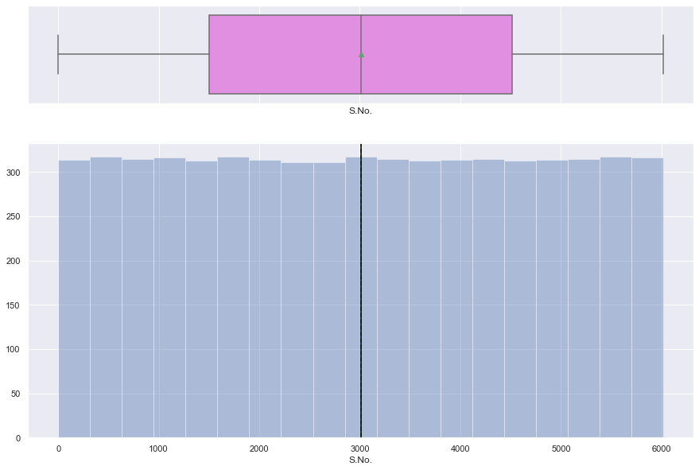

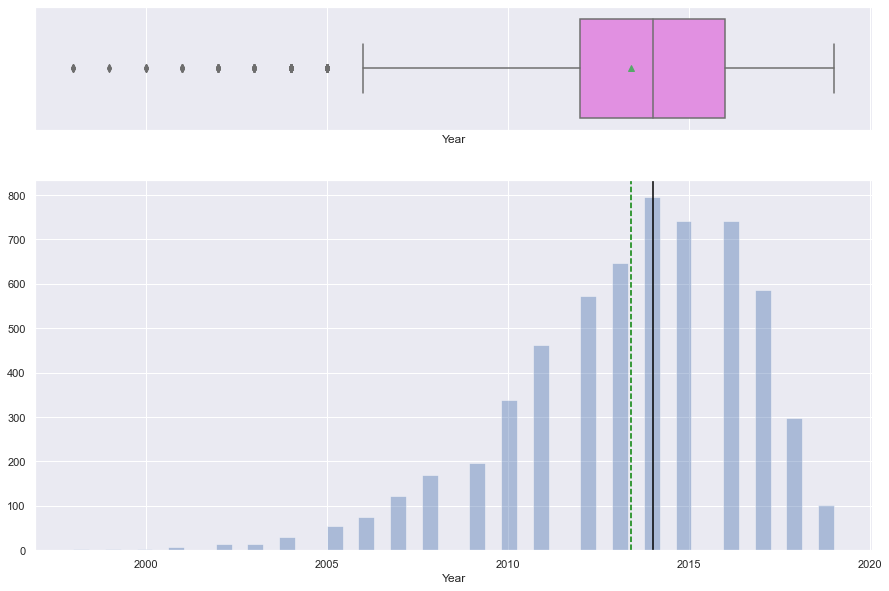

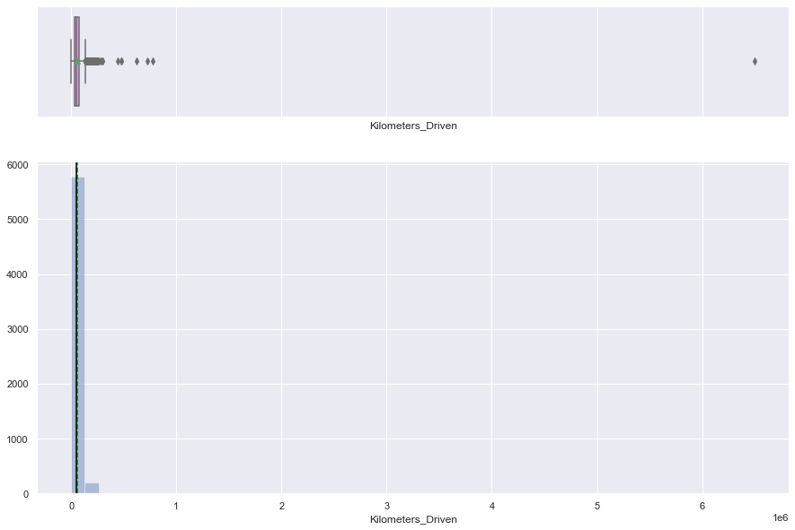

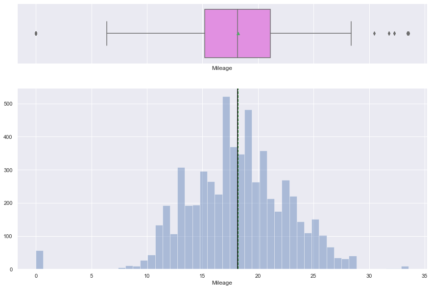

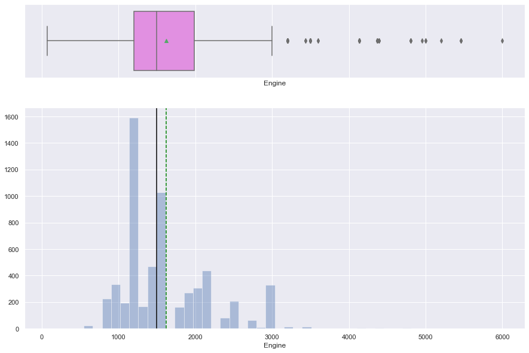

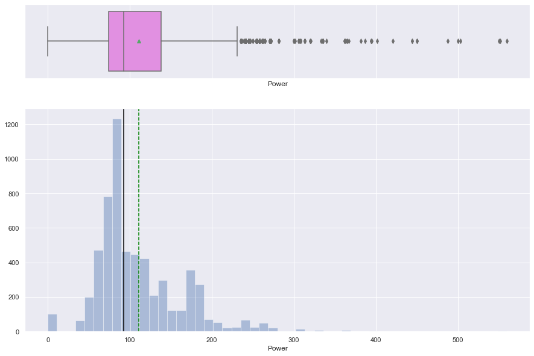

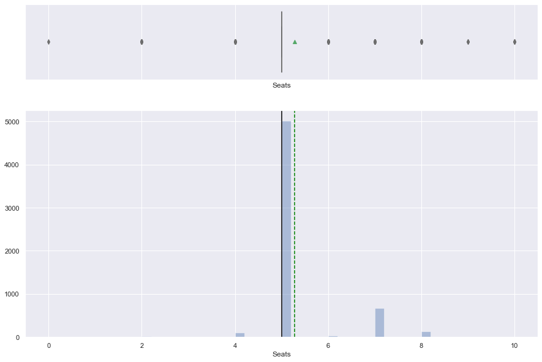

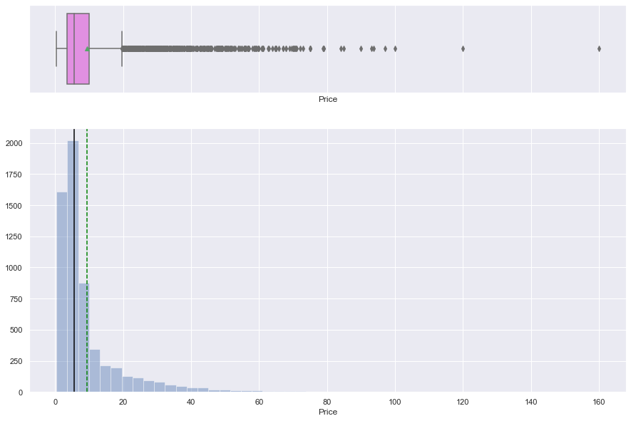

```python
for col in numerical_columns:
    histogram_boxplot(cars_eda[col])
```

##### Distributions

- *'S.No.'* has uniform distribution
- *'Year'* is skewed to the left with most values between 2009 and 2018
- _'Kilometers*Driven'* is highly skewed to the right with one or more extreme outliers
- *'Mileage'* has a close to normal distribution with a number of outliers grouped at zero
- *'Engine'* has a multimodal distribution with many values between 1000 and 2000. It is also skewed to the right with some outliers
- Seats is not a continuous variable and although it is numeric, we will change to be a categorical type
- Price is highly skewed to the right with two or more extreme outliers
- *'Power'* is highly skewed to the right

We will review each variable.

##### 'Kilometers_Driven'

```python
cars_eda['Kilometers_Driven'].describe()
```

```
count    5.977000e+03
mean     5.867041e+04
std      9.154346e+04
min      1.710000e+02
25%      3.391500e+04
50%      5.300000e+04
75%      7.300000e+04
max      6.500000e+06
Name: Kilometers_Driven, dtype: float64
```

There are two orders of magnitude difference between the 75-th percentile and the maximum.

We'll review percentiles closer to the extreme of the range.

```python
km_col = 'Kilometers_Driven'
km_percentiles = cars_eda[km_col].quantile([.01,.05,.90,.95,.99])
km_percentiles
```

```
0.01      4013.68
0.05     13000.00
0.90     96672.00
0.95    120000.00
0.99    172278.00
Name: Kilometers_Driven, dtype: float64
```

```python
# Review the values above 99-th percentile
cars_eda[[km_col, 'Year']][cars_eda[km_col] > km_percentiles.loc[0.99]].sort_values(by=km_col, ascending=False).head(20)
```

|  | Kilometers_Driven | Year |
| --- | --- | --- |
| 2328 | 6500000 | 2017 |
| 340 | 775000 | 2013 |
| 1860 | 720000 | 2013 |
| 358 | 620000 | 2009 |
| 3092 | 480000 | 2015 |
| 2823 | 480000 | 2015 |
| 4491 | 445000 | 2013 |
| 3649 | 300000 | 2008 |
| 1528 | 299322 | 2005 |
| 1975 | 282000 | 2012 |
| 29 | 262000 | 2007 |
| 1846 | 255000 | 2013 |
| 3894 | 250000 | 2010 |
| 4719 | 250000 | 2014 |
| 5834 | 250000 | 2013 |
| 1101 | 248000 | 2011 |
| 4792 | 242000 | 2010 |
| 2988 | 240000 | 2005 |
| 2346 | 234000 | 2013 |
| 3713 | 232000 | 2009 |

One entry stands out with a huge value which seems unrealistic especially given the manufacturing year. It is probably a data entry error.

```python
cars_eda.loc[2328]
```

```
S.No.                                     2328
Name                 BMW X5 xDrive 30d M Sport
Location                               Chennai
Year                                      2017
Kilometers_Driven                      6500000
Fuel_Type                               Diesel
Transmission                         Automatic
Owner_Type                               First
Mileage                                  15.97
Engine                                    2993
Power                                      258
Seats                                        5
Price                                       65
Name: 2328, dtype: object
```

All the other values for that record look reasonable. We'll replace the value with the median value from cars in the same year.

```
Before and after distribution of "Kilometers_Driven"
```

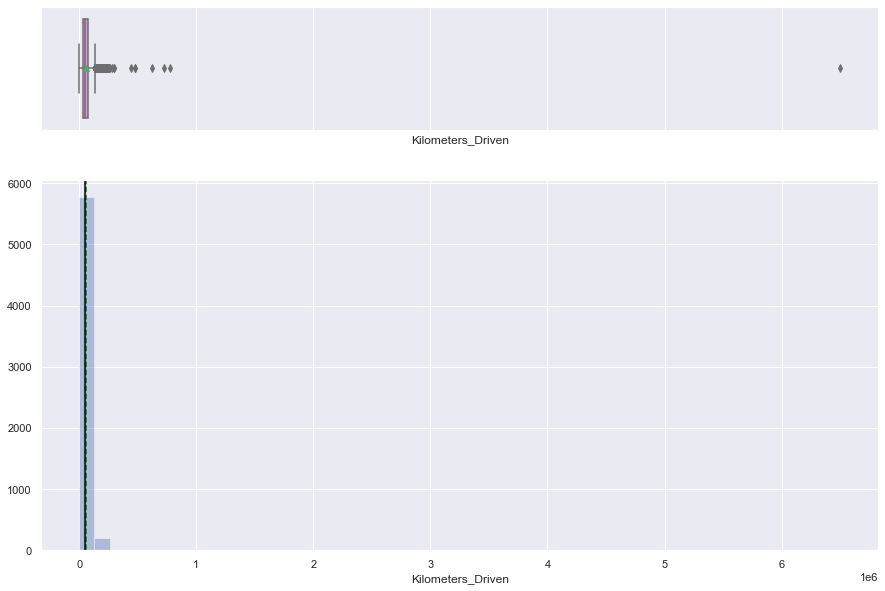

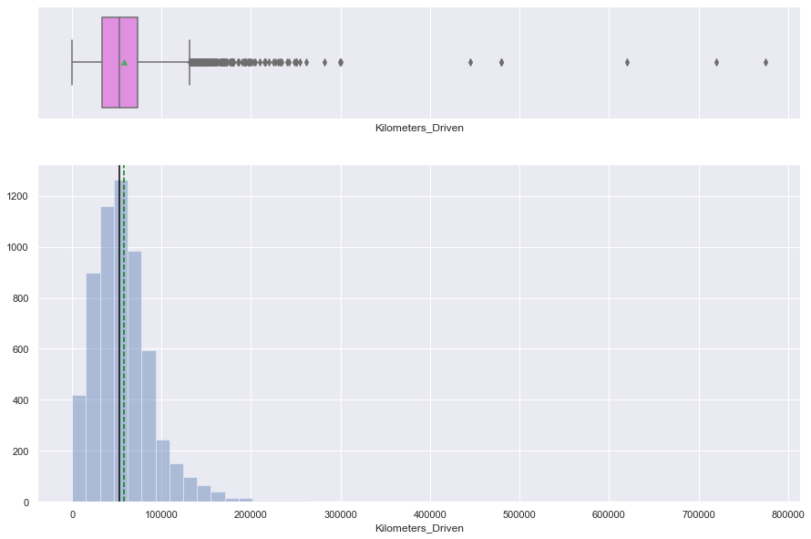

```python
# assign the kilometers_driven median of cars of the same year to the outlier
loc = 2328
year = cars_eda['Year'].loc[loc]
km_median = cars[km_col][cars['Year'] == year].median()
cars_eda[km_col].loc[loc] = km_median

# compare the before and after distributions
print(f'Before and after distribution of "Kilometers_Driven"')
histogram_boxplot(cars[km_col])
histogram_boxplot(cars_eda[km_col])
```

The distribution is much improved. It is still very skewed to the right. We'll try to use log transformation to see if it improves.

```python
# Check for zero values first
cars_eda[km_col][cars_eda[km_col] < 0.1].count()
```

```
0
```

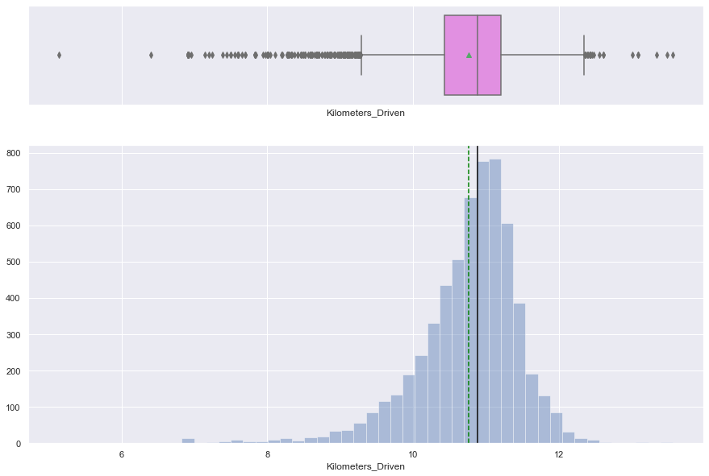

```python
# get series with log value
km_log = np.log(cars_eda[km_col])
histogram_boxplot(km_log)
```

The distribution is improved but now we have a left skew.

We will now look at the lower end of range.

```python
cars_eda[[km_col, 'Year']][cars_eda[km_col] < km_percentiles.loc[0.01]].sort_values(by=km_col, ascending=True).head(20)
```

|  | Kilometers_Driven | Year |
| --- | --- | --- |
| 1361 | 171 | 2019 |
| 5606 | 600 | 2019 |
| 173 | 1000 | 2019 |
| 5339 | 1000 | 2019 |
| 2646 | 1000 | 2019 |
| 1161 | 1000 | 2018 |
| 5941 | 1000 | 2018 |
| 1198 | 1000 | 2019 |
| 2054 | 1000 | 2017 |
| 1242 | 1000 | 2018 |
| 1598 | 1000 | 2017 |
| 5249 | 1001 | 2018 |
| 1726 | 1001 | 2015 |
| 3769 | 1011 | 2018 |
| 5966 | 1048 | 2018 |
| 2119 | 1261 | 2007 |
| 601 | 1331 | 2018 |
| 5516 | 1400 | 2018 |
| 5829 | 1617 | 2018 |
| 1704 | 1700 | 2018 |

These values seem reasonable, especially as they apply to more recent cars.

we will leave the 'Km_log' as is, add it to the datframe and drop the 'Kilometers_Driven' column

```python
# add log Km
cars_eda['Km_log'] = km_log

# drop original column
cars_eda.drop('Kilometers_Driven', axis=1, inplace=True)
```

##### Mileage

```python
# get statistics
mileage_col = 'Mileage'
cars_eda[mileage_col].describe()
```

```
count    5976.000000
mean       18.180366
std         4.522030
min         0.000000
25%        15.200000
50%        18.160000
75%        21.100000
max        33.540000
Name: Mileage, dtype: float64
```

```python
# get percentiles closer to extreme of the range
mileage_prct = cars_eda[mileage_col].quantile([.01,.05,.90,.95,.99])
mileage_prct
```

```
0.01     7.94
0.05    11.50
0.90    24.00
0.95    25.47
0.99    28.09
Name: Mileage, dtype: float64
```

Let's view the values below the 1-percentile

```python
# Check the lowest values
cars_eda[[mileage_col, 'Engine']][cars_eda[mileage_col] < mileage_prct.loc[0.01]].sort_values(by=mileage_col, ascending=True).head(20)
```

|  | Mileage | Engine |
| --- | --- | --- |
| 14 | 0.0 | 2179.0 |
| 3033 | 0.0 | 1086.0 |
| 3044 | 0.0 | 1086.0 |
| 3061 | 0.0 | 999.0 |
| 3093 | 0.0 | 2967.0 |
| 3189 | 0.0 | 999.0 |
| 3210 | 0.0 | 2987.0 |
| 3271 | 0.0 | 1086.0 |
| 3516 | 0.0 | 1086.0 |
| 3645 | 0.0 | 1086.0 |
| 4234 | 0.0 | 2987.0 |
| 4302 | 0.0 | 1086.0 |
| 4412 | 0.0 | 2987.0 |
| 4629 | 0.0 | 1242.0 |
| 4687 | 0.0 | 2179.0 |
| 4704 | 0.0 | 2987.0 |
| 5016 | 0.0 | 2179.0 |
| 5022 | 0.0 | 2179.0 |
| 5119 | 0.0 | 1086.0 |
| 5311 | 0.0 | 2179.0 |

```python
# Check the highest below the 1-percentile
cars_eda[[mileage_col, 'Engine']][cars_eda[mileage_col] < mileage_prct.loc[0.01]].sort_values(by=mileage_col, ascending=True).tail(20)
```

|  | Mileage | Engine |
| --- | --- | --- |
| 707 | 0.00 | 2987.0 |
| 2343 | 0.00 | 999.0 |
| 962 | 0.00 | 1950.0 |
| 915 | 0.00 | 799.0 |
| 1059 | 0.00 | 1086.0 |
| 1259 | 0.00 | 2179.0 |
| 1271 | 0.00 | 999.0 |
| 1308 | 0.00 | 2987.0 |
| 1345 | 0.00 | 1590.0 |
| 1354 | 0.00 | 1086.0 |
| 1419 | 0.00 | 1086.0 |
| 1764 | 0.00 | 2987.0 |
| 1857 | 0.00 | 999.0 |
| 2053 | 0.00 | 2498.0 |
| 2130 | 0.00 | 999.0 |
| 996 | 0.00 | 1086.0 |
| 6011 | 0.00 | 3597.0 |
| 5781 | 6.40 | 5204.0 |
| 5603 | 7.50 | 4806.0 |
| 152 | 7.81 | 5461.0 |

Many values are zero, the lowest non-zero value is 6.40, which is reasonable given the displacement of the engine

```python
cars_eda.isnull().sum()
```

```
S.No.           0
Name            0
Location        0
Year            0
Fuel_Type       0
Transmission    0
Owner_Type      0
Mileage         1
Engine          0
Power           0
Seats           0
Price           0
Km_log          0
dtype: int64
```

We will first take care of the missing value by capping it to the maximum of the Mileage range instead of using the actual value. This is to prevent it from strongly skewing the mileage data.

```python
cars_eda[cars_eda.Mileage.isnull()]
```

|  | S.No. | Name | Location | Year | Fuel_Type | Transmission | Owner_Type | Mileage | Engine | Power | Seats | Price | Km_log |
| --- | --- | --- | --- | --- | --- | --- | --- | --- | --- | --- | --- | --- | --- |
| 4446 | 4446 | Mahindra E Verito D4 | Chennai | 2016 | Electric | Automatic | First | NaN | 72.0 | 41.0 | 5.0 | 13.0 | 10.819778 |

```python
cars_eda['Mileage'][cars_eda.Mileage.isnull()] = cars_eda['Mileage'].max()
```

```python
cars_eda.loc[4446]
```

```
S.No.                           4446
Name            Mahindra E Verito D4
Location                     Chennai
Year                            2016
Fuel_Type                   Electric
Transmission               Automatic
Owner_Type                     First
Mileage                        33.54
Engine                            72
Power                             41
Seats                              5
Price                             13
Km_log                       10.8198
Name: 4446, dtype: object
```

```python
# count zero Mileage values
mileage_min = 6.40
zero_mil_idx = cars_eda[cars_eda[mileage_col] < mileage_min].index
cars_eda.loc[zero_mil_idx].count()
```

```
S.No.           56
Name            56
Location        56
Year            56
Fuel_Type       56
Transmission    56
Owner_Type      56
Mileage         56
Engine          56
Power           56
Seats           56
Price           56
Km_log          56
dtype: int64
```

There are 56 values with zero 'Mileage' - we will impute the values using the meadian of car with similar 'Engine' values

```python
# Assign np.nan to zero values so we can compute the medians without the zero values skew
cars_eda[mileage_col].loc[zero_mil_idx] = np.nan

# For each location assign the 'Mileage' median of similarly sized engine
distance = 500
for loc in zero_mil_idx:
    eng = cars_eda['Engine'].loc[loc]
    median_mileage = cars_eda[mileage_col][(cars['Engine'] > eng - distance) & (cars['Engine'] < eng + distance)].median()
    cars_eda[mileage_col].loc[loc] = median_mileage
```

```
Mileage: Distributions before and after zero-values rows
```

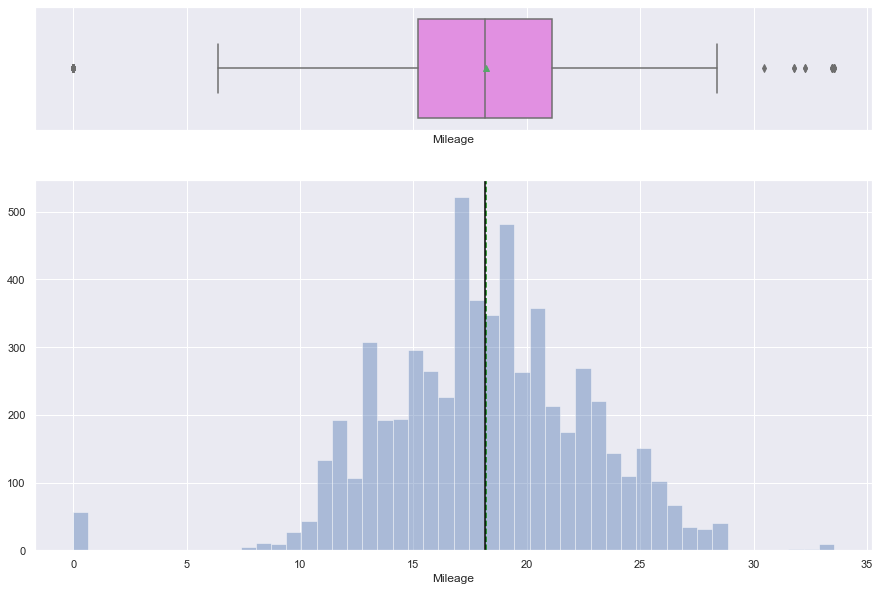

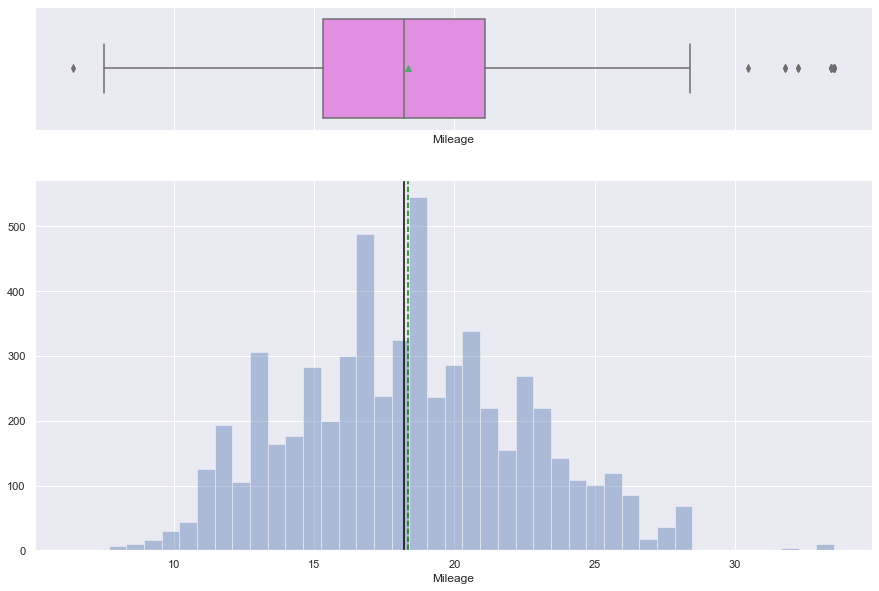

```python
# compare the before and after distributions
print(f'Mileage: Distributions before and after zero-values rows')
histogram_boxplot(cars[mileage_col])
histogram_boxplot(cars_eda[mileage_col])
```

The zero values where removed but that didn't change much the distribution. There is a slight right skew and a number of outliers near the range maximum.

The outliers are few, we will leave the data as is.

##### Seats

```python
# Seats statistics
cars_eda['Seats'].describe()
```

```
count    5977.000000
mean        5.278735
std         0.808840
min         0.000000
25%         5.000000
50%         5.000000
75%         5.000000
max        10.000000
Name: Seats, dtype: float64
```

```python
# Seats counts
seats_col = 'Seats'
cars_eda[seats_col].value_counts()
```

```
5.0     5014
7.0      674
8.0      134
4.0       99
6.0       31
2.0       16
10.0       5
9.0        3
0.0        1
Name: Seats, dtype: int64
```

There is only one invalid value with zero. We'll drop that record.

```python
# drop rows with zero seats
invalid_seats = cars_eda[cars_eda[seats_col] == 0.0].index
cars_eda.drop(invalid_seats, axis=0, inplace=True)
```

Seats is now ready to be converted to categorical. We will do that later on after we review other categorical variables.

```python
cars_eda.info()
```

```
<class 'pandas.core.frame.DataFrame'>
Int64Index: 5976 entries, 0 to 6018
Data columns (total 13 columns):
 #   Column        Non-Null Count  Dtype
---  ------        --------------  -----
 0   S.No.         5976 non-null   int64
 1   Name          5976 non-null   object
 2   Location      5976 non-null   object
 3   Year          5976 non-null   int64
 4   Fuel_Type     5976 non-null   object
 5   Transmission  5976 non-null   object
 6   Owner_Type    5976 non-null   object
 7   Mileage       5976 non-null   float64
 8   Engine        5976 non-null   float64
 9   Power         5976 non-null   float64
 10  Seats         5976 non-null   float64
 11  Price         5976 non-null   float64
 12  Km_log        5976 non-null   float64
dtypes: float64(6), int64(2), object(5)
memory usage: 653.6+ KB
```

##### Power

Check for zeros

```python
power_col = 'Power'
# check values close to zero
cars_eda[power_col][cars_eda[power_col] < 0.1].count()
```

```
102
```

There are 102 values with zero, we will impute the values using the median Power of cars with similar Engine (displacement)

```python
zero_pow_idx = cars_eda[cars_eda[power_col] < 0.1].index
```

```python
# Assign np.nan to zero values so we can compute the medians without the zero values skew
cars_eda[power_col].loc[zero_pow_idx] = np.nan

# For each location assign the 'Mileage' median of similarly sized engine
distance = 500
for loc in zero_pow_idx:
    eng = cars_eda['Engine'].loc[loc]
    median_power = cars_eda[power_col][(cars['Engine'] > eng - distance) & (cars['Engine'] < eng + distance)].median()
    cars_eda[power_col].loc[loc] = median_power
```

```python
# check for zero values of power
cars_eda[power_col][cars_eda[power_col] < 0.1].count()
```

```
0
```

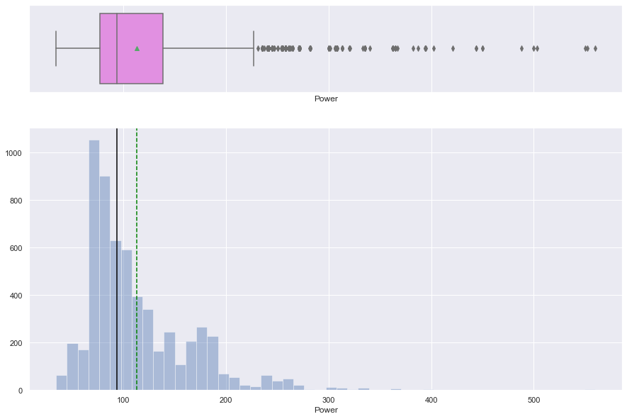

```python
# check distribution
histogram_boxplot(cars_eda[power_col])
```

Distribution is still highly skewed to the right.

We will try log transformation.

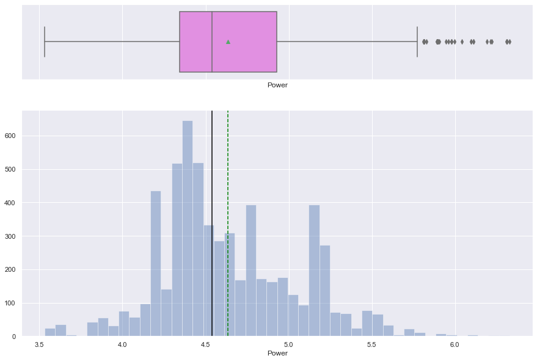

```python
power_log = np.log(cars_eda[power_col])
histogram_boxplot(power_log)
```

The distribution is still somewhat skewed to the right but still an improvement over the raw data.

We will drop 'Power' and add 'Power_log' to the features

```python
# drop Power , add Power_log
cars_eda['Power_log'] = power_log
cars_eda.drop('Power', axis=1, inplace=True)
```

##### Price

```python
# Price statistics
cars_eda['Price'].describe()
```

```
count    5976.000000
mean        9.501354
std        11.204429
min         0.440000
25%         3.500000
50%         5.650000
75%         9.952500
max       160.000000
Name: Price, dtype: float64
```

The maximum value is very high - we'll review the values near the range maximum

```python
# get percentiles for price near the range max
price_percentiles = cars_eda['Price'].quantile([.75, .9, .95, .99, .995, .999])
price_percentiles
```

```
0.750     9.9525
0.900    22.5000
0.950    32.5000
0.990    56.0350
0.995    67.0000
0.999    90.0750
Name: Price, dtype: float64
```

```python
##### get all cars above 99.5-th percentile
cars_eda[cars_eda['Price'] >= price_percentiles.loc[0.995]].sort_values(by='Price', ascending=False)
```

|  | S.No. | Name | Location | Year | Fuel_Type | Transmission | Owner_Type | Mileage | Engine | Seats | Price | Km_log | Power_log |
| --- | --- | --- | --- | --- | --- | --- | --- | --- | --- | --- | --- | --- | --- |
| 4079 | 4079 | Land Rover Range Rover 3.0 Diesel LWB Vogue | Hyderabad | 2017 | Diesel | Automatic | First | 13.33 | 2993.0 | 5.0 | 160.00 | 10.126631 | 5.541264 |
| 5781 | 5781 | Lamborghini Gallardo Coupe | Delhi | 2011 | Petrol | Automatic | Third | 6.40 | 5204.0 | 2.0 | 120.00 | 8.779557 | 6.327937 |
| 5919 | 5919 | Jaguar F Type 5.0 V8 S | Hyderabad | 2015 | Petrol | Automatic | First | 12.50 | 5000.0 | 2.0 | 100.00 | 8.987197 | 6.190520 |
| 1505 | 1505 | Land Rover Range Rover Sport SE | Kochi | 2019 | Diesel | Automatic | First | 12.65 | 2993.0 | 5.0 | 97.07 | 10.166352 | 5.541264 |
| 1974 | 1974 | BMW 7 Series 740Li | Coimbatore | 2018 | Petrol | Automatic | First | 12.05 | 2979.0 | 5.0 | 93.67 | 10.242100 | 5.768321 |
| 1984 | 1984 | BMW 7 Series 740Li | Bangalore | 2017 | Petrol | Automatic | First | 12.05 | 2979.0 | 5.0 | 93.00 | 9.767954 | 5.768321 |
| 4691 | 4691 | Mercedes-Benz SLK-Class 55 AMG | Bangalore | 2014 | Petrol | Automatic | Second | 12.00 | 5461.0 | 2.0 | 90.00 | 8.006368 | 6.042633 |
| 5535 | 5535 | BMW X6 xDrive 40d M Sport | Ahmedabad | 2015 | Diesel | Automatic | First | 15.87 | 2993.0 | 5.0 | 85.00 | 11.482497 | 5.731495 |
| 2095 | 2095 | Mercedes-Benz SLC 43 AMG | Coimbatore | 2019 | Petrol | Automatic | First | 19.00 | 2996.0 | 2.0 | 83.96 | 7.834392 | 5.891838 |
| 1885 | 1885 | Mercedes-Benz GLS 350d Grand Edition | Delhi | 2018 | Diesel | Automatic | First | 11.00 | 2987.0 | 7.0 | 79.00 | 8.699515 | 5.552960 |
| 2422 | 2422 | Jaguar XJ 3.0L Portfolio | Delhi | 2016 | Diesel | Automatic | First | 10.50 | 2993.0 | 4.0 | 79.00 | 9.392662 | 5.602967 |
| 2319 | 2319 | Mercedes-Benz E-Class E 350 d | Coimbatore | 2019 | Diesel | Automatic | First | 18.00 | 2987.0 | 5.0 | 78.80 | 9.139059 | 5.552960 |
| 655 | 655 | Jaguar XJ 2.0L Portfolio | Mumbai | 2017 | Petrol | Automatic | First | 9.43 | 1999.0 | 5.0 | 75.00 | 9.259226 | 5.469746 |
| 2659 | 2659 | Porsche Panamera Diesel | Kolkata | 2015 | Diesel | Automatic | First | 17.85 | 2967.0 | 4.0 | 75.00 | 10.130623 | 5.703782 |
| 2907 | 2907 | Jaguar XJ 3.0L Portfolio | Hyderabad | 2015 | Diesel | Automatic | First | 14.47 | 2993.0 | 5.0 | 75.00 | 10.165852 | 5.709533 |
| 3489 | 3489 | Porsche Panamera Diesel | Bangalore | 2013 | Diesel | Automatic | Second | 17.85 | 2967.0 | 4.0 | 75.00 | 9.894850 | 5.703782 |
| 1583 | 1583 | Audi Q7 45 TDI Quattro Premium Plus | Kochi | 2019 | Diesel | Automatic | First | 14.75 | 2967.0 | 7.0 | 72.94 | 8.820699 | 5.501258 |
| 5603 | 5603 | Porsche Panamera 2010 2013 Diesel | Delhi | 2013 | Diesel | Automatic | First | 7.50 | 4806.0 | 4.0 | 72.00 | 10.502324 | 5.977112 |
| 418 | 418 | Mercedes-Benz GLC 43 AMG Coupe | Coimbatore | 2018 | Petrol | Automatic | First | 11.50 | 2996.0 | 5.0 | 70.99 | 10.016682 | 5.905362 |
| 1690 | 1690 | Mercedes-Benz GLE 350d | Coimbatore | 2018 | Diesel | Automatic | First | 11.57 | 2987.0 | 5.0 | 70.80 | 10.599855 | 5.540440 |
| 3752 | 3752 | Land Rover Range Rover Sport HSE | Kochi | 2015 | Diesel | Automatic | First | 12.65 | 2993.0 | 5.0 | 70.66 | 10.557556 | 5.541264 |
| 282 | 282 | Audi Q7 3.0 TDI Quattro Technology | Kochi | 2018 | Diesel | Automatic | First | 12.07 | 2967.0 | 7.0 | 70.36 | 9.331407 | 5.486455 |
| 2541 | 2541 | Mercedes-Benz E-Class 2015-2017 E350 CDI Avant... | Kochi | 2018 | Diesel | Automatic | First | 13.00 | 2987.0 | 5.0 | 70.15 | 9.980587 | 5.579730 |
| 4614 | 4614 | BMW X5 X5 M | Chennai | 2017 | Diesel | Automatic | First | 15.97 | 2993.0 | 5.0 | 70.00 | 9.615805 | 5.552960 |
| 1352 | 1352 | Land Rover Range Rover 3.6 TDV8 Vogue SE Diesel | Bangalore | 2012 | Diesel | Automatic | First | 10.20 | 4367.0 | 7.0 | 70.00 | 11.105528 | 5.730100 |
| 1194 | 1194 | Mercedes-Benz E-Class 2015-2017 E350 CDI Avant... | Mumbai | 2017 | Diesel | Automatic | First | 13.00 | 2987.0 | 5.0 | 69.50 | 9.615805 | 5.579730 |
| 4360 | 4360 | BMW 6 Series Gran Coupe | Kochi | 2018 | Diesel | Automatic | First | 17.54 | 2993.0 | 4.0 | 68.94 | 9.903688 | 5.746203 |
| 5009 | 5009 | Audi Q7 45 TDI Quattro Technology | Pune | 2017 | Diesel | Automatic | First | 14.75 | 2967.0 | 7.0 | 68.00 | 10.993732 | 5.501258 |
| 5341 | 5341 | Porsche Cayenne S Diesel | Coimbatore | 2016 | Diesel | Automatic | First | 13.60 | 4134.0 | 5.0 | 67.83 | 11.082189 | 5.945421 |
| 1038 | 1038 | Land Rover Range Rover TDV8 (Diesel) | Bangalore | 2011 | Diesel | Automatic | First | 10.20 | 4367.0 | 7.0 | 67.00 | 10.915088 | 5.730100 |
| 1336 | 1336 | Audi Q7 45 TDI Quattro Technology | Mumbai | 2016 | Diesel | Automatic | First | 14.75 | 2967.0 | 7.0 | 67.00 | 9.903588 | 5.501258 |

Highest priced cars are from a small number of brands (Mercedes-Benz, BMW, Audi, Porsche, Land Rover, etc.)

The two largest outlier are from the Land Rover Range Rover 3.0 Diesel LWB Vogue and the Lamborghini Gallardo Coupe. The price is close to the new retail price, so it does not seem to be invalid data. However, it will skew the data considerably.

Let's review the distribution with and without those record.

```python
cars_eda['Price'].describe()
```

```
count    5976.000000
mean        9.501354
std        11.204429
min         0.440000
25%         3.500000
50%         5.650000
75%         9.952500
max       160.000000
Name: Price, dtype: float64
```

```python
cars_eda['Price'].drop([4079,5781], axis=0).describe()
```

```
count    5974.000000
mean        9.457665
std        10.942720
min         0.440000
25%         3.500000
50%         5.650000
75%         9.950000
max       100.000000
Name: Price, dtype: float64
```

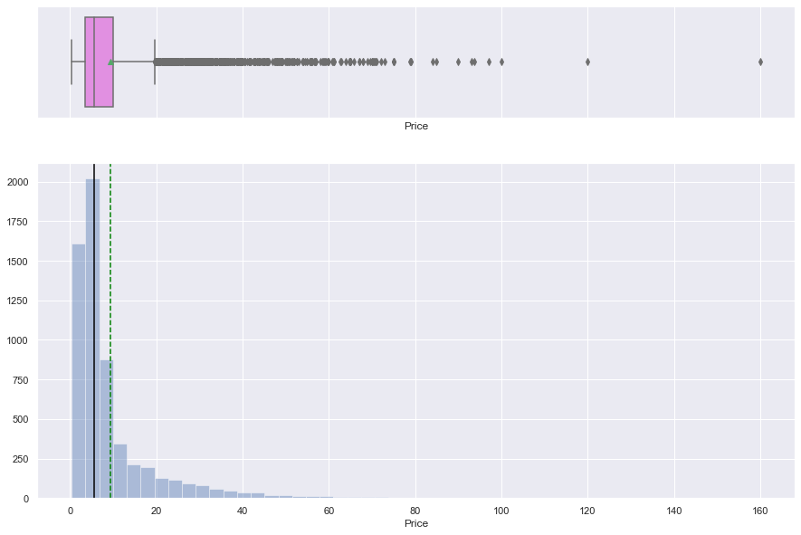

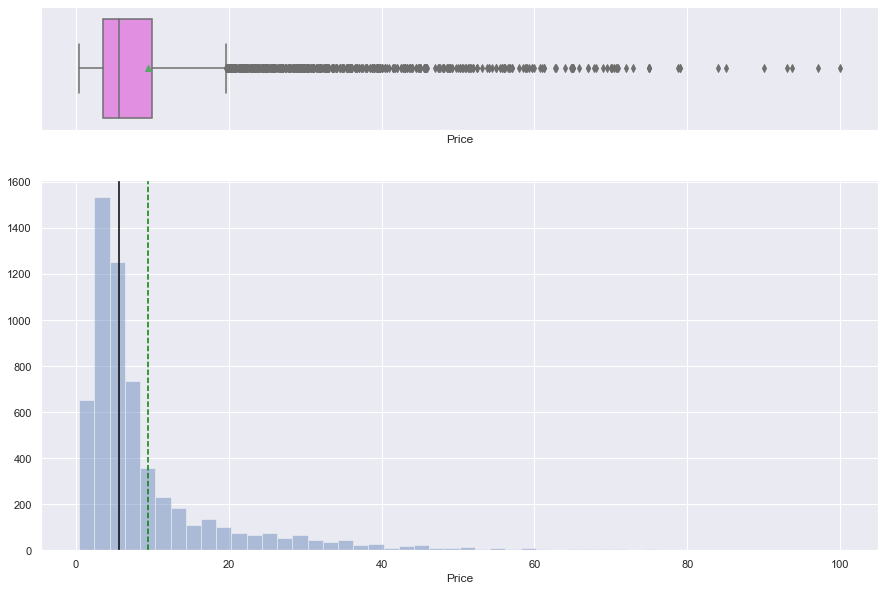

```python
histogram_boxplot(cars_eda['Price'])
histogram_boxplot(cars_eda['Price'].drop([4079,5781], axis=0))
```

The Price distribution remains highly skewed even after removing those outliers.

Also removing the two largest outliers did not change percentiles and std deviation significantly.

However, while doing preliminary bivariate analysis, the scatterplots of price against other variables improved significantly (visually) when those two outliers were removed. We will drop those rows from the dataset.

```python
# Drop dream cars
cars_eda = cars_eda.drop([4079,5781], axis=0)
```

##### Numerical variables scaling.

Because some numerical variables have different orders of magnitudes (fro example, 'Mileage' is typically two orders of magnitude lower than 'Engine'), it would be difficult to interpret the importance a certain feature has based on the coefficients of unscaled variables.

We will use a MinMax scaler to scale variables in the range 0 to 1 (default).

```python
# create a minmax scaler
from sklearn.preprocessing import MinMaxScaler
minmax_scaler = MinMaxScaler()
```

```python
# list the data types
cars_eda.dtypes
```

```
S.No.             int64
Name             object
Location         object
Year              int64
Fuel_Type        object
Transmission     object
Owner_Type       object
Mileage         float64
Engine          float64
Seats           float64
Price           float64
Km_log          float64
Power_log       float64
dtype: object
```

```python
# get statistics before the scaling
cars_eda.describe()
```

|  | S.No. | Year | Mileage | Engine | Seats | Price | Km_log | Power_log |
| --- | --- | --- | --- | --- | --- | --- | --- | --- |
| count | 5974.000000 | 5974.000000 | 5974.000000 | 5974.000000 | 5974.000000 | 5974.000000 | 5974.000000 | 5974.000000 |
| mean | 3008.557750 | 2013.386843 | 18.348482 | 1620.283897 | 5.280214 | 9.457665 | 10.756280 | 4.634967 |
| std | 1739.246233 | 3.247299 | 4.174594 | 599.026248 | 0.805028 | 10.942720 | 0.713594 | 0.413838 |
| min | 0.000000 | 1998.000000 | 7.500000 | 72.000000 | 2.000000 | 0.440000 | 5.141664 | 3.532226 |
| 25% | 1502.250000 | 2012.000000 | 15.300000 | 1198.000000 | 5.000000 | 3.500000 | 10.431731 | 4.341530 |
| 50% | 3009.500000 | 2014.000000 | 18.200000 | 1493.000000 | 5.000000 | 5.650000 | 10.878047 | 4.540098 |
| 75% | 4514.750000 | 2016.000000 | 21.100000 | 1984.000000 | 5.000000 | 9.950000 | 11.198215 | 4.927978 |
| max | 6018.000000 | 2019.000000 | 33.540000 | 5998.000000 | 10.000000 | 100.000000 | 13.560618 | 6.313548 |

```python
# scale the variables
minmax_columns = ['Year','Mileage','Engine','Power_log','Km_log']
cars_eda[minmax_columns] = minmax_scaler.fit_transform(cars_eda[minmax_columns])
```

```python
# get statistics after scaling
cars_eda.describe()
```

|  | S.No. | Year | Mileage | Engine | Seats | Price | Km_log | Power_log |
| --- | --- | --- | --- | --- | --- | --- | --- | --- |
| count | 5974.000000 | 5974.000000 | 5974.000000 | 5974.000000 | 5974.000000 | 5974.000000 | 5974.000000 | 5974.000000 |
| mean | 3008.557750 | 0.732707 | 0.416608 | 0.261270 | 5.280214 | 9.457665 | 0.666902 | 0.396481 |
| std | 1739.246233 | 0.154633 | 0.160315 | 0.101084 | 0.805028 | 10.942720 | 0.084760 | 0.148792 |
| min | 0.000000 | 0.000000 | 0.000000 | 0.000000 | 2.000000 | 0.440000 | 0.000000 | 0.000000 |
| 25% | 1502.250000 | 0.666667 | 0.299539 | 0.190010 | 5.000000 | 3.500000 | 0.628352 | 0.290978 |
| 50% | 3009.500000 | 0.761905 | 0.410906 | 0.239791 | 5.000000 | 5.650000 | 0.681365 | 0.362372 |
| 75% | 4514.750000 | 0.857143 | 0.522273 | 0.322646 | 5.000000 | 9.950000 | 0.719395 | 0.501831 |
| max | 6018.000000 | 1.000000 | 1.000000 | 1.000000 | 10.000000 | 100.000000 | 1.000000 | 1.000000 |

#### Univariate Analysis - Categorical Variables

```python
# get rows and columns counts
cars_eda.shape
```

```
(5974, 13)
```

```python
# get data types
cars_eda.dtypes
```

```
S.No.             int64
Name             object
Location         object
Year            float64
Fuel_Type        object
Transmission     object
Owner_Type       object
Mileage         float64
Engine          float64
Seats           float64
Price           float64
Km_log          float64
Power_log       float64
dtype: object
```

##### Name

```python
cars_eda['Name'].value_counts()
```

```
Mahindra XUV500 W8 2WD            49
Maruti Swift VDI                  45
Honda City 1.5 S MT               34
Maruti Swift Dzire VDI            34
Maruti Swift VDI BSIV             31
                                  ..
Volkswagen Beetle 2.0              1
Maruti Swift Dzire LXi             1
Chevrolet Captiva LTZ VCDi         1
Skoda Superb 1.8 TSI               1
Mitsubishi Pajero 2.8 SFX 7Str     1
Name: Name, Length: 1854, dtype: int64
```

```python
# function to extract trailing part of string after separator
def get_trailing_words(value, separator=" "):
    '''Return trailing part of string after first occurence of separator'''
    if isinstance(value, str):
        if separator in value:
            return ''.join(value.split(separator, maxsplit=1)[1:])
        else:
            return value
    else:
        return np.nan
```

```python
# create new columns for 'Make' and 'Model'
split_columns_transform = {
    'Make': get_first_word,
    'Model': get_trailing_words
}

for col,func in split_columns_transform.items():
    cars_eda[col] = cars_eda['Name'].map(func)
```

```python
# view data after the split
cars_eda[['Name','Make','Model']]
```

|  | Name | Make | Model |
| --- | --- | --- | --- |
| 0 | Maruti Wagon R LXI CNG | Maruti | Wagon R LXI CNG |
| 1 | Hyundai Creta 1.6 CRDi SX Option | Hyundai | Creta 1.6 CRDi SX Option |
| 2 | Honda Jazz V | Honda | Jazz V |
| 3 | Maruti Ertiga VDI | Maruti | Ertiga VDI |
| 4 | Audi A4 New 2.0 TDI Multitronic | Audi | A4 New 2.0 TDI Multitronic |
| ... | ... | ... | ... |
| 6014 | Maruti Swift VDI | Maruti | Swift VDI |
| 6015 | Hyundai Xcent 1.1 CRDi S | Hyundai | Xcent 1.1 CRDi S |
| 6016 | Mahindra Xylo D4 BSIV | Mahindra | Xylo D4 BSIV |
| 6017 | Maruti Wagon R VXI | Maruti | Wagon R VXI |
| 6018 | Chevrolet Beat Diesel | Chevrolet | Beat Diesel |

5974 rows × 3 columns

##### Make

```python
len(cars_eda['Make'].unique())
```

```
30
```

There are 30 distinct brands. That would add too many columns to the features if each was encoded.

We will keep the top 10 makes and assign the rest to 'Others'

```python
# get the top 10 makes
make_counts = cars_eda['Make'].value_counts().head(10)
make_counts
```

```
Maruti           1197
Hyundai          1100
Honda             601
Toyota            410
Mercedes-Benz     318
Volkswagen        315
Ford              298
Mahindra          272
BMW               262
Audi              235
Name: Make, dtype: int64
```

```python
# get the list of makes to be retained
makes_list = make_counts.index.tolist()
makes_list
```

```
['Maruti',
 'Hyundai',
 'Honda',
 'Toyota',
 'Mercedes-Benz',
 'Volkswagen',
 'Ford',
 'Mahindra',
 'BMW',
 'Audi']
```

```python
# assign 'Other' to makes not in the top 10
make_other_idx = cars_eda[~cars_eda['Make'].isin(makes_list)].index
cars_eda['Make'].loc[make_other_idx] = "Other"
```

```python
# view new 'Make' counts
cars_eda['Make'].value_counts()
```

```
Maruti           1197
Hyundai          1100
Other             966
Honda             601
Toyota            410
Mercedes-Benz     318
Volkswagen        315
Ford              298
Mahindra          272
BMW               262
Audi              235
Name: Make, dtype: int64
```

##### Model

We'll now review 'Model'

```python
cars_eda['Model'].value_counts()
```

```
XUV500 W8 2WD                  49
Swift VDI                      45
City 1.5 S MT                  34
Swift Dzire VDI                34
Swift VDI BSIV                 31
                               ..
V40 D3 R Design                 1
Sunny Diesel XV                 1
Figo 1.5D Titanium Plus MT      1
KUV 100 mFALCON D75 K4 Plus     1
Scorpio 1.99 S4 Plus            1
Name: Model, Length: 1854, dtype: int64
```

```python
cars_eda['Model'].value_counts().head(20)
```

```
XUV500 W8 2WD          49
Swift VDI              45
City 1.5 S MT          34
Swift Dzire VDI        34
Swift VDI BSIV         31
i10 Sportz             30
Ritz VDi               30
Fortuner 3.0 Diesel    29
Grand i10 Sportz       27
Amaze S i-Dtech        27
Ertiga VDI             25
Brio S MT              25
City 1.5 V MT          24
Verna 1.6 SX           23
Wagon R VXI            23
Wagon R LXI            22
Alto LXi               21
3 Series 320d          20
Alto 800 LXI           20
EON Era Plus           20
Name: Model, dtype: int64
```

Although 'Model' likely has high predictive power, there are too many entries to be used for linear regression. Again we will use the top 10 and set the rest to 'Other'

```python
# get the model counts and plot the model counts
model_counts = cars_eda['Model'].value_counts().head(10)
```

```python
model_list = model_counts.index.tolist()
model_list
```

```
['XUV500 W8 2WD',
 'Swift VDI',
 'City 1.5 S MT',
 'Swift Dzire VDI',
 'Swift VDI BSIV',
 'i10 Sportz',
 'Ritz VDi',
 'Fortuner 3.0 Diesel',
 'Grand i10 Sportz',
 'Amaze S i-Dtech']
```

```python
# Set make to 'Other' for makes with count below threshold
model_other_idx = cars_eda[~cars_eda['Model'].isin(model_list)].index
cars_eda['Model'].loc[model_other_idx] = "Other"
```

```python
cars_eda['Model'].value_counts()
```

```
Other                  5638
XUV500 W8 2WD            49
Swift VDI                45
Swift Dzire VDI          34
City 1.5 S MT            34
Swift VDI BSIV           31
i10 Sportz               30
Ritz VDi                 30
Fortuner 3.0 Diesel      29
Grand i10 Sportz         27
Amaze S i-Dtech          27
Name: Model, dtype: int64
```

The value 'Other' has the highest count which is much higher than the second highest. As each Model is a small percentage of the total number of rows, this variable will not be useful in training the model. We will deal with it later after reviewing all categorical variables.

We will drop 'Name'.

```python
# drop Name
cars_eda.drop('Name', axis=1, inplace=True)
```

##### Location

```python
# get Location counts
cars_eda['Location'].value_counts()
```

```
Mumbai        785
Hyderabad     739
Kochi         648
Coimbatore    634
Pune          613
Delhi         548
Kolkata       530
Chennai       491
Jaipur        410
Bangalore     353
Ahmedabad     223
Name: Location, dtype: int64
```

There is a limited number of locations and they all have meaningful values. We'll leave location as is.

##### Fuel_Type

```python
cars_eda['Fuel_Type'].value_counts()
```

```
Diesel      3194
Petrol      2712
CNG           56
LPG           10
Electric       2
Name: Fuel_Type, dtype: int64
```

The 'Fuel_Type' looks to be properly populated and with a small number of unique values - we will leave as is

##### Transmission

```python
cars_eda['Transmission'].value_counts()
```

```
Manual       4266
Automatic    1708
Name: Transmission, dtype: int64
```

The 'Transmission' looks to be properly populated and with a small number of unique values - we will leave as is.

##### Owner_Type

```python
cars_eda['Owner_Type'].value_counts()
```

```
First             4903
Second             953
Third              110
Fourth & Above       8
Name: Owner_Type, dtype: int64
```

#### Plot categorical variables

We'll now look at plots for the categorical variables

```python
# Function to plot categories as percent of total
def perc_on_bar(data, z):
    """
    plot categorical var data[z] in bars with percentages
    """
    total = len(data[z])  # length of the column
    plt.figure(figsize=(15, 5))
    plt.xticks(rotation=45)
    ax = sns.countplot(data[z], palette="Paired")
    for p in ax.patches:
        percentage = "{:.1f}%".format(
            100 * p.get_height() / total
        )  # percentage of each class of the category
        x = p.get_x() + p.get_width() / 2 - 0.05  # width of the plot
        y = p.get_y() + p.get_height()  # hieght of the plot

        ax.annotate(percentage, (x, y), size=10)  # annotate the percantage
    plt.show()  # show the plot
```

```python
# plot percentages for all categorical variables
# Get categorical columns
categ_vars = cars_eda.select_dtypes(['object']).columns.tolist()
# categ_vars.extend(cars_eda.columns[cars_eda.dtypes == 'object'])
categ_vars
```

```
['Location', 'Fuel_Type', 'Transmission', 'Owner_Type', 'Make', 'Model']
```

#### Categorical variables breakdown by percentage + price distribution by category

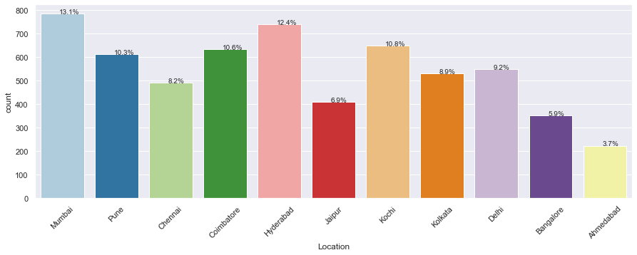

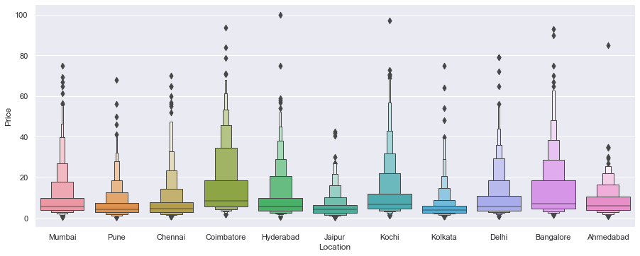

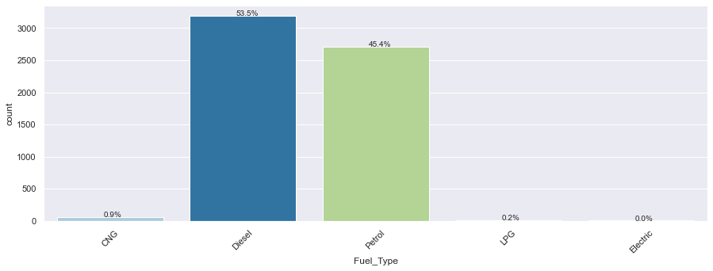

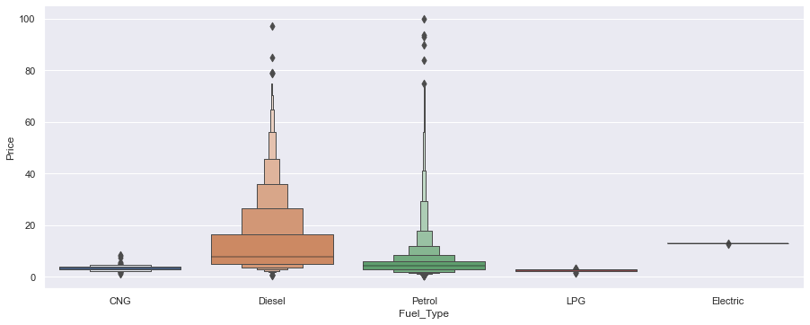

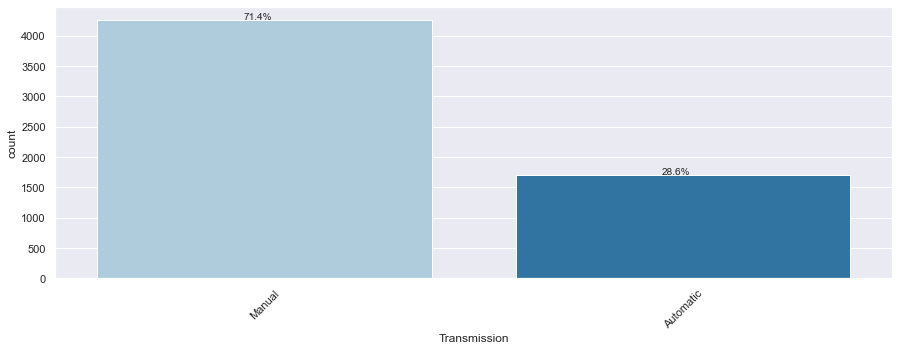

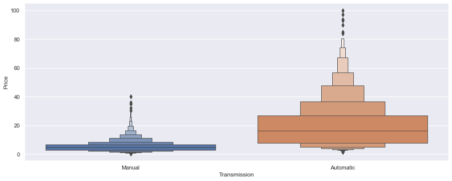

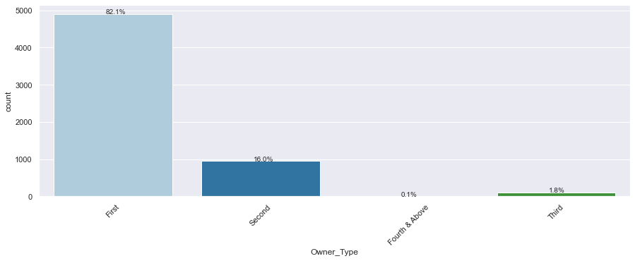

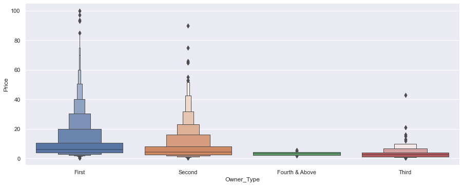

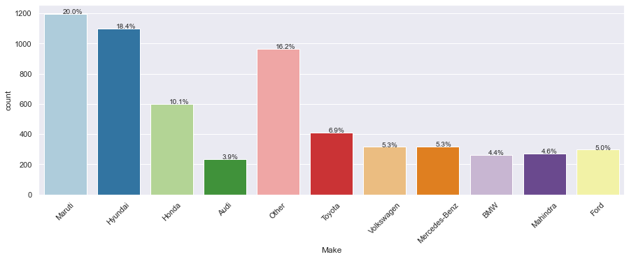

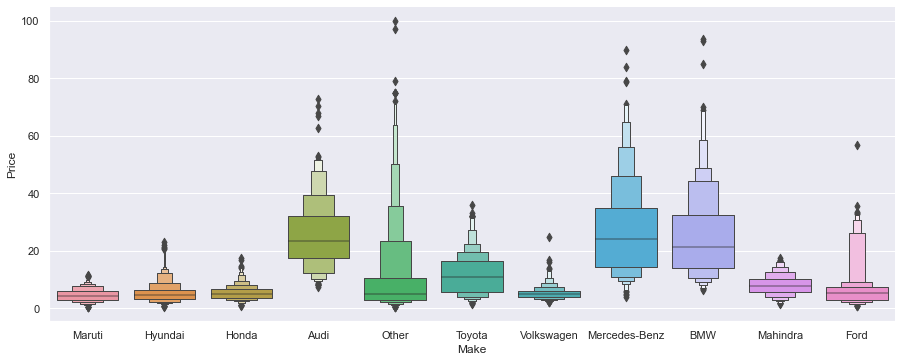

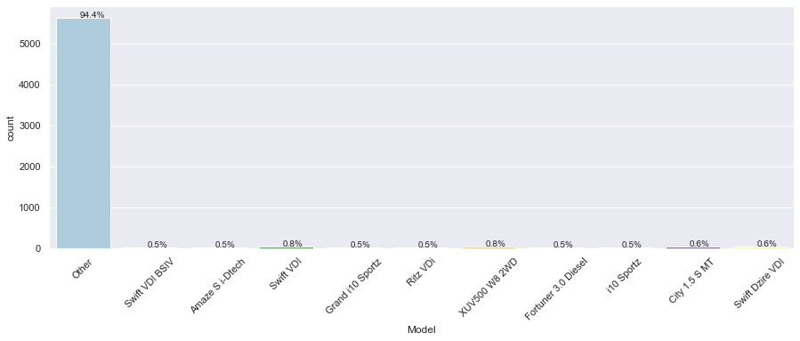

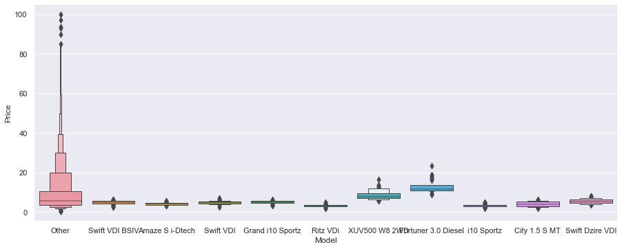

```python
for col in categ_vars:
    perc_on_bar(cars_eda, col)
    sns.catplot(y='Price', x=col, data=cars_eda, kind='boxen', height=5, aspect=2.5)
```

'Model' is dominated by value 'Other' with 94.4% of the rows. As is, 'Model' is likely not going to be a good predictor for price.

We will drop 'Model'

98+% of 'Fuel_Type' is either 'Diesel' or 'Petrol' with Price median higher for Diesel.

More cars have 'Transmission' of type 'Manual' (71%). Price being significantly higher for 'Automatic'.

'Owner_Type' is mostly 'First' (82%) followed by 'Second' (16%). Prices tend to be higher for 'First'.

'Seats' is mostly 5 at 84%, followed by 7 at 11%. Price distribution for 'Seats' shows a significantly higher price for cars with 'Seats' = 2

'Make' show Maruti at the top with 20% share, followed by 'Hyundai' at 18%. 'Other' represent 16%. Prices are significantly higher for luxury brands such as Audi, BMW and Mercedes-Benz.

```python
# drop 'Model' from dataset
cars_eda.drop('Model', axis=1, inplace=True)
```

We will now cast columns of type 'object' to categorical

```python
cars_eda.dtypes
```

```
S.No.             int64
Location         object
Year            float64
Fuel_Type        object
Transmission     object
Owner_Type       object
Mileage         float64
Engine          float64
Seats           float64
Price           float64
Km_log          float64
Power_log       float64
Make             object
dtype: object
```

Although 'Seats' is currently numerical, it should be treated as a categorical variable, so we'll cast it to 'category' as well.

```python
# Fetch categorical variables again, since we dropped some columns
categ_vars = []
categ_vars.extend(cars_eda.columns[cars_eda.dtypes == 'object'])

# Append 'Seats'
categ_vars.append('Seats')
categ_vars
```

```
['Location', 'Fuel_Type', 'Transmission', 'Owner_Type', 'Make', 'Seats']
```

```python
# cast to category dtype
cars_eda[categ_vars] = cars_eda[categ_vars].astype('category')

# check dtypes
cars_eda.dtypes
```

```
S.No.              int64
Location        category
Year             float64
Fuel_Type       category
Transmission    category
Owner_Type      category
Mileage          float64
Engine           float64
Seats           category
Price            float64
Km_log           float64
Power_log        float64
Make            category
dtype: object
```

```python
# get dataframe details
cars_eda.info()
```

```
<class 'pandas.core.frame.DataFrame'>
Int64Index: 5974 entries, 0 to 6018
Data columns (total 13 columns):
 #   Column        Non-Null Count  Dtype
---  ------        --------------  -----
 0   S.No.         5974 non-null   int64
 1   Location      5974 non-null   category
 2   Year          5974 non-null   float64
 3   Fuel_Type     5974 non-null   category
 4   Transmission  5974 non-null   category
 5   Owner_Type    5974 non-null   category
 6   Mileage       5974 non-null   float64
 7   Engine        5974 non-null   float64
 8   Seats         5974 non-null   category
 9   Price         5974 non-null   float64
 10  Km_log        5974 non-null   float64
 11  Power_log     5974 non-null   float64
 12  Make          5974 non-null   category
dtypes: category(6), float64(6), int64(1)
memory usage: 570.0 KB
```

### Multi-variate Analysis

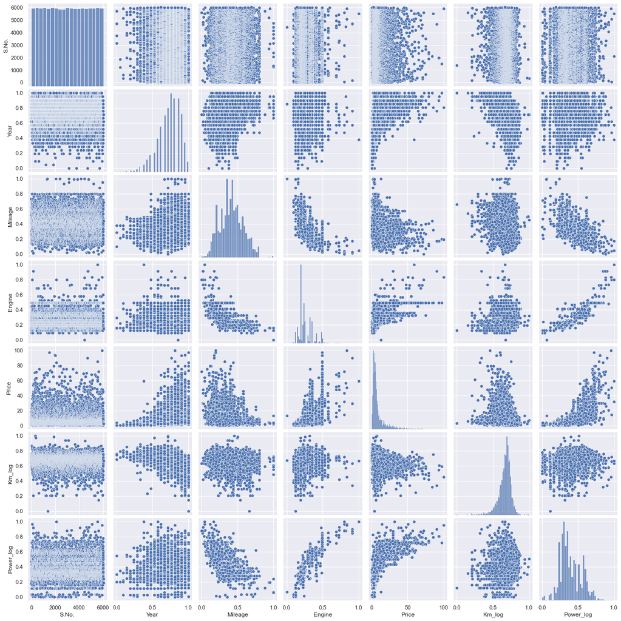

```python
sns.pairplot(cars_eda)
```

Distributions look acceptable and improved over the original dataset.

Scatterplots against Price do not show clear correlations aside from Price and Power_log.

We will use the correlation matrix to get a better sense of the correlations.

There seems to be no correlation between 'S.No.' and price or any other numerical variable. We will verify that by checking correlations matrix.

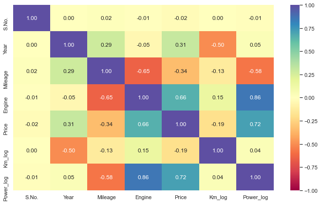

```python
# plot correlation matrix
plt.figure(figsize=(12, 7))
sns.heatmap(
    cars_eda.corr(), annot=True, vmin=-1, vmax=1, fmt=".2f", cmap="Spectral"
)
plt.show()
```

Price has correlation to 'Power_log' and 'Engine' and a weak correlation with Mileage and Year.

Correlations between 'S.No' and any other variables are zero or near zero. We will drop 'S.No.' column

```python
cars_eda.drop('S.No.', axis=1, inplace=True)
```

### Model Building

#### Creating dummy variables

We will now encode the categorical variables using dummy variables. I.e. $n-1$ columns will be created for each categorical variables with $n$ levels

```python
# Make a copy of the DataFrame
cars_processed = cars_eda.copy()

# Separate the target variable from independent variables
X_df = cars_processed.drop(['Price'], axis=1, inplace=False)
y_df = cars_processed[['Price']]
```

```python
X_df.columns
```

```
Index(['Location', 'Year', 'Fuel_Type', 'Transmission', 'Owner_Type',
       'Mileage', 'Engine', 'Seats', 'Km_log', 'Power_log', 'Make'],
      dtype='object')
```

```python
# Get categorical columns
categ_vars = []
categ_vars.extend(X_df.columns[X_df.dtypes == 'category'])
categ_vars
```

```
['Location', 'Fuel_Type', 'Transmission', 'Owner_Type', 'Seats', 'Make']
```

```python
def encode_cat_vars(x_vars):
    ''' Return a dataframe with all columns of type object and category converted to dummy variables '''
    x = pd.get_dummies(
        x_vars,
        columns=x_vars.select_dtypes(include=["object", "category"]).columns.tolist(),
        drop_first=True
    )
    return x

X_num = encode_cat_vars(X_df)
X_num.head()
```

|  | Year | Mileage | Engine | Km_log | Power_log | Location_Bangalore | Location_Chennai | Location_Coimbatore | Location_Delhi | Location_Hyderabad | Location_Jaipur | Location_Kochi | Location_Kolkata | Location_Mumbai | Location_Pune | Fuel_Type_Diesel | Fuel_Type_Electric | Fuel_Type_LPG | Fuel_Type_Petrol | Transmission_Manual | Owner_Type_Fourth & Above | Owner_Type_Second | Owner_Type_Third | Seats_4.0 | Seats_5.0 | Seats_6.0 | Seats_7.0 | Seats_8.0 | Seats_9.0 | … |
| --- | --- | --- | --- | --- | --- | --- | --- | --- | --- | --- | --- | --- | --- | --- | --- | --- | --- | --- | --- | --- | --- | --- | --- | --- | --- | --- | --- | --- | --- | --- |
| 0 | 0.571429 | 0.733487 | 0.156261 | 0.717756 | 0.190906 | 0 | 0 | 0 | 0 | 0 | 0 | 0 | 0 | 1 | 0 | 0 | 0 | 0 | 0 | 1 | 0 | 0 | 0 | 0 | 1 | 0 | 0 | 0 | 0 | … |
| 1 | 0.809524 | 0.467358 | 0.254809 | 0.650872 | 0.469432 | 0 | 0 | 0 | 0 | 0 | 0 | 0 | 0 | 0 | 1 | 1 | 0 | 0 | 0 | 1 | 0 | 0 | 0 | 0 | 1 | 0 | 0 | 0 | 0 | … |
| 2 | 0.619048 | 0.410906 | 0.190179 | 0.664540 | 0.342655 | 0 | 1 | 0 | 0 | 0 | 0 | 0 | 0 | 0 | 0 | 0 | 0 | 0 | 1 | 1 | 0 | 0 | 0 | 0 | 1 | 0 | 0 | 0 | 0 | … |
| 3 | 0.666667 | 0.509601 | 0.198448 | 0.740234 | 0.342898 | 0 | 1 | 0 | 0 | 0 | 0 | 0 | 0 | 0 | 0 | 1 | 0 | 0 | 0 | 1 | 0 | 0 | 0 | 0 | 0 | 0 | 1 | 0 | 0 | … |
| 4 | 0.714286 | 0.295699 | 0.319946 | 0.649912 | 0.508792 | 0 | 0 | 1 | 0 | 0 | 0 | 0 | 0 | 0 | 0 | 1 | 0 | 0 | 0 | 0 | 0 | 1 | 0 | 0 | 1 | 0 | 0 | 0 | 0 | … |

```python
# Check the number of rows and columns in the new dataframe
X_num.shape
```

```
(5974, 40)
```

We now have 40 features.

##### Split the data in train and test datasets

```python
# Split the data sets into train and test data
from sklearn.model_selection import train_test_split

x_train, x_test, y_train, y_test = train_test_split(X_num, y_df, test_size=0.3, random_state=117)
```

```python
# check shape of train independent vars
x_train.shape
```

```
(4181, 40)
```

```python
# check shape of test independent vars
x_test.shape
```

```
(1793, 40)
```

```python
# check shape of train dependent vars
y_train.shape
```

```
(4181, 1)
```

```python
# check shape of test dependent var
y_test.shape
```

```
(1793, 1)
```

##### Train a linear regression model

```python
# train the model
linr_model = LinearRegression()
linr_model.fit(X=x_train, y=y_train)
```

```
LinearRegression()
```

```python
# show coefficients
coeff_df = pd.DataFrame(
    np.append(linr_model.coef_.flatten(), linr_model.intercept_),
    index=x_train.columns.tolist() + ['Intercept'],
    columns=['Coefficients'],
)
coeff_df
```

|  | Coefficients |
| --- | --- |
| Year | 18.412495 |
| Mileage | -4.615619 |
| Engine | 33.370452 |
| Km_log | -14.643344 |
| Power_log | 19.007692 |
| Location_Bangalore | 2.119125 |
| Location_Chennai | 1.047577 |
| Location_Coimbatore | 2.164052 |
| Location_Delhi | -0.277316 |
| Location_Hyderabad | 1.777734 |
| Location_Jaipur | 0.685388 |
| Location_Kochi | 0.226254 |
| Location_Kolkata | -1.517309 |
| Location_Mumbai | -1.125463 |
| Location_Pune | 0.299853 |
| Fuel_Type_Diesel | -0.084795 |
| Fuel_Type_Electric | 9.948438 |
| Fuel_Type_LPG | 1.884337 |
| Fuel_Type_Petrol | -1.736091 |
| Transmission_Manual | -1.654986 |
| Owner_Type_Fourth & Above | -1.307502 |
| Owner_Type_Second | -0.424108 |
| Owner_Type_Third | 0.921098 |
| Seats_4.0 | -5.557529 |
| Seats_5.0 | -13.203345 |
| Seats_6.0 | -14.536709 |
| Seats_7.0 | -13.069520 |
| Seats_8.0 | -13.937648 |
| Seats_9.0 | -16.582462 |
| Seats_10.0 | -17.764364 |
| Make_BMW | -0.340926 |
| Make_Ford | -6.902277 |
| Make_Honda | -7.652277 |
| Make_Hyundai | -6.183056 |
| Make_Mahindra | -11.527964 |
| Make_Maruti | -4.452169 |
| Make_Mercedes-Benz | 0.906538 |
| Make_Other | -5.239201 |
| Make_Toyota | -8.177216 |
| Make_Volkswagen | -7.815213 |
| Intercept | 11.570592 |